# Porcine Pancreas Ductal Organoids - 01 - Filtering and Imputation

- Show All Code
- Hide All Code
- View Source

Author

Falk Janos Farkas

Published

August 15, 2025

# 1 Experimental Setup

Comparison of proteome between porcine pancreatic ductal organoids of different passages and donor ages. Organoids were derived from Embryonic, early postnatal and adult animals and cultured. For the early postnatal derived organoids, early and late passages were used to isolate proteins and investigate proteomic differences.

## 1.1 Saving

# 2 Load Data

```r
filename <- "KAK386_Pig_BSG_PGSpec_Spec20.xlsx"

samples <- read_excel(paste(path_results, filename, sep = "/"), col_names = T , sheet = "Sample sheet")



data <- read_excel(paste(path_results, "20250806_clean_data_KAC386_Pig_organoids.xlsx", sep = "/"), col_names = T )
dim(data)
```

```
[1] 8433   18
```

```r
data %>% head
```

```
# A tibble: 6 × 18
  Accession  Genes  Description    Min_Peptides_quantif…¹ Max_Peptides_quantif…²
  <chr>      <chr>  <chr>                           <dbl>                  <dbl>
1 A0A023VTS2 SAMHD1 Deoxynucleosi…                     21                     39
2 A0A076V355 FZD6   Frizzled-6                          5                     10
3 A0A0B8RS50 ZNF654 Zinc finger p…                      5                      6
4 A0A0B8RS56 XRN1   5'-3' exoribo…                     17                     37
5 A0A0B8RS58 WBP11  WW domain bin…                     12                     17
6 A0A0B8RS77 TEC    Tyrosine-prot…                      0                      4
# ℹ abbreviated names: ¹Min_Peptides_quantified, ²Max_Peptides_quantified
# ℹ 13 more variables: Min_Peptides_identified <dbl>, CK1_3 <dbl>, CK1_2 <dbl>,
#   CK2 <dbl>, CK3 <dbl>, CK4 <dbl>, CK5 <dbl>, CK6 <dbl>, CK7 <dbl>,
#   CK8 <dbl>, CK9 <dbl>, CK10 <dbl>, CK11 <dbl>
```

```r
sample_color_pallette <- c(viridis(3,begin = 0.005, end = 0.40), viridis(4,begin = 0.55, end = 0.97))

sample_color <- c( "#99d8c9","#238A8DFF", "#2ca25f", "#deebf7" ,"#a6bddb", "#2b8cbe" ,"#f19fdd" ,"#fa9fb5","#c51b8a","#FDE725FF", "#fec44f","#e34a33" )

names(sample_color) <- samples %>% pull(Sample)
sample_color_vec <- sample_color
```

# 3 Remove NA and make gene names unique

```r
paste("How many of the total Accessions in the dataset are unique per segment and fraction?")
```

```
[1] "How many of the total Accessions in the dataset are unique per segment and fraction?"
```

```r
data  %>% summarise(Unique_Accession= n_distinct( (Accession)),
                                                 Accession_count = length(Accession), .groups = "drop")
```

```
# A tibble: 1 × 2
  Unique_Accession Accession_count
             <int>           <int>
1             8433            8433
```

```r
paste("How many of the total Genes in the dataset are unique per segment and fraction?")
```

```
[1] "How many of the total Genes in the dataset are unique per segment and fraction?"
```

```r
data  %>% summarise(Unique_Genes= n_distinct( (Genes)),
                                                 Gene_count = length(Genes), .groups = "drop")
```

```
# A tibble: 1 × 2
  Unique_Genes Gene_count
         <int>      <int>
1         8433       8433
```

```r
paste("All Genes and Accessions are Unique!")
```

```
[1] "All Genes and Accessions are Unique!"
```

Data is good to continue with.

## 3.1 Experimental Design

```r
# generate a experimental design dataframe to establish a SummarizedExperiment
columns <- samples %>% pull(Sample)


#columns

exp_design <- samples %>% dplyr::rename(
  label = Sample,
  replicate = Replicate
) %>% select(-Condition)


print("Esperimental Design:")
```

```
[1] "Esperimental Design:"
```

```r
exp_design
```

```
# A tibble: 12 × 3
   label replicate condition
   <chr>     <dbl> <chr>
 1 CK1_3         1 Embryo
 2 CK1_2         2 Embryo
 3 CK2           3 Embryo
 4 CK3           1 PN_earlyP
 5 CK4           2 PN_earlyP
 6 CK5           3 PN_earlyP
 7 CK6           1 PN_lateP
 8 CK7           2 PN_lateP
 9 CK8           3 PN_lateP
10 CK9           1 Adult
11 CK10          2 Adult
12 CK11          3 Adult
```

## 3.2 Generate SummarizedExperiment

```r
# Step 2: Apply make_unique and make_se to each split
data %>%    make_unique("Genes", "Accession", delim = "_") %>%    make_se(columns = columns, expdesign = exp_design, log2transform = TRUE ) -> data_se

colData(data_se)$label <- factor( colData(data_se)$label,  levels = names(sample_color) )
colData(data_se)
```

```
DataFrame with 12 rows and 4 columns
               label            ID replicate   condition
            <factor>   <character> <numeric> <character>
Embryo_1       CK1_3      Embryo_1         1      Embryo
Embryo_2       CK1_2      Embryo_2         2      Embryo
Embryo_3       CK2        Embryo_3         3      Embryo
PN_earlyP_1    CK3   PN_earlyP_...         1   PN_earlyP
PN_earlyP_2    CK4   PN_earlyP_...         2   PN_earlyP
...              ...           ...       ...         ...
PN_lateP_2      CK7     PN_lateP_2         2    PN_lateP
PN_lateP_3      CK8     PN_lateP_3         3    PN_lateP
Adult_1         CK9        Adult_1         1       Adult
Adult_2         CK10       Adult_2         2       Adult
Adult_3         CK11       Adult_3         3       Adult
```

# 4 Filtering

## 4.1 Missing Values pre filtering

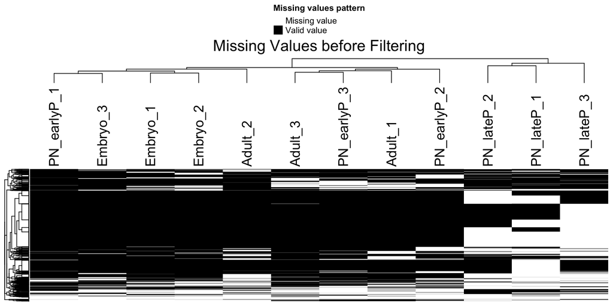

```r
  plot_missval(data_se, column_title = "Missing Values before Filtering" ,column_title_gp = gpar(fontsize = 18.2))
```

## 4.2 Filtering of missing values

```r
data_filter <- filter_se(data_se, thr = 1, fraction = 2/12)
```

```
filter base on missing number is <= 1 in at least one condition.
```

```
filter base on missing number fraction < 0.166666666666667 in each row
```

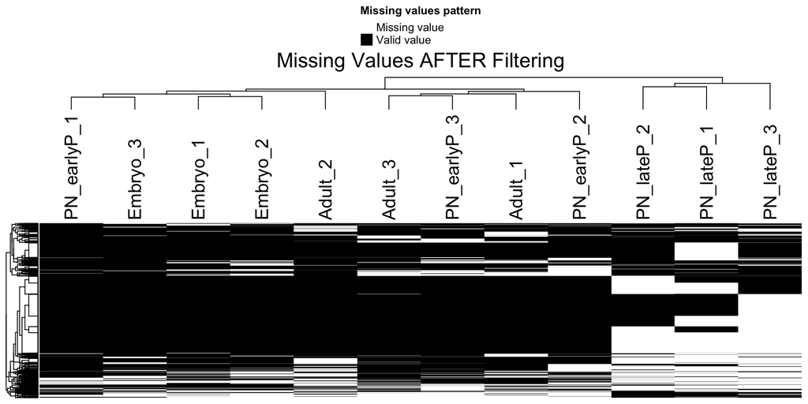

```r
  plot_missval(data_filter, column_title = "Missing Values AFTER Filtering" ,column_title_gp = gpar(fontsize = 18.2))
```

## 4.3 plotting frequencies values before and after filtering

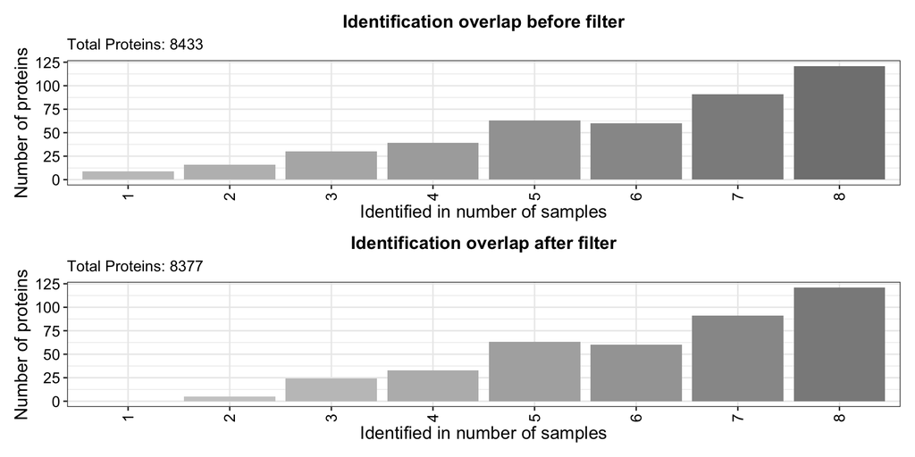

```r
p <- plot_frequency(data_se)+
  ggtitle(paste("Identification overlap before filter"), subtitle = paste("Total Proteins:" , nrow(data_se)))+
            scale_x_discrete(limits = as.character(1:8))


pp <- plot_frequency(data_filter)+
  ggtitle(paste("Identification overlap after filter"), subtitle = paste("Total Proteins:" , nrow(data_filter)))+
            scale_x_discrete(limits = as.character(1:8) )

print(p/pp)
```

# 5 Equalize Variances between samples - Normalization

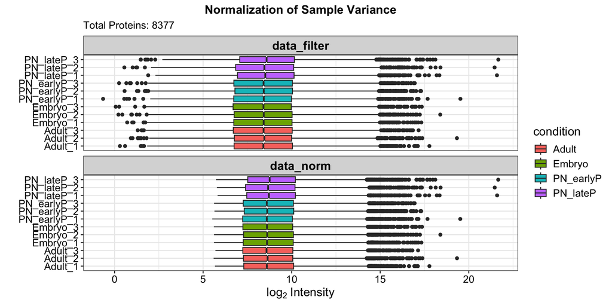

```r
data_filter %>% normalize_vsn() -> data_norm

p<- plot_normalization(data_filter,data_norm) +
    ggtitle( paste("Normalization of Sample Variance"), subtitle = paste("Total Proteins:" , nrow(data_norm)))

print(p)
```

# 6 Selecting Imputation Method

```r
set.seed(09051997)
```

## 6.1 Missing at Random or not at random

Are the missing values missing randomly dispersed through the data, or is missingness more of a feature because the different samples acquire different trajectories and hence different proteomes. Here, it is more MNAR (missing not at random), a lot of proteins are either present in Organoids of early passage or late. Missingness correlates with sample condition and is not at random.

## 6.2 MNAR vs. MAR

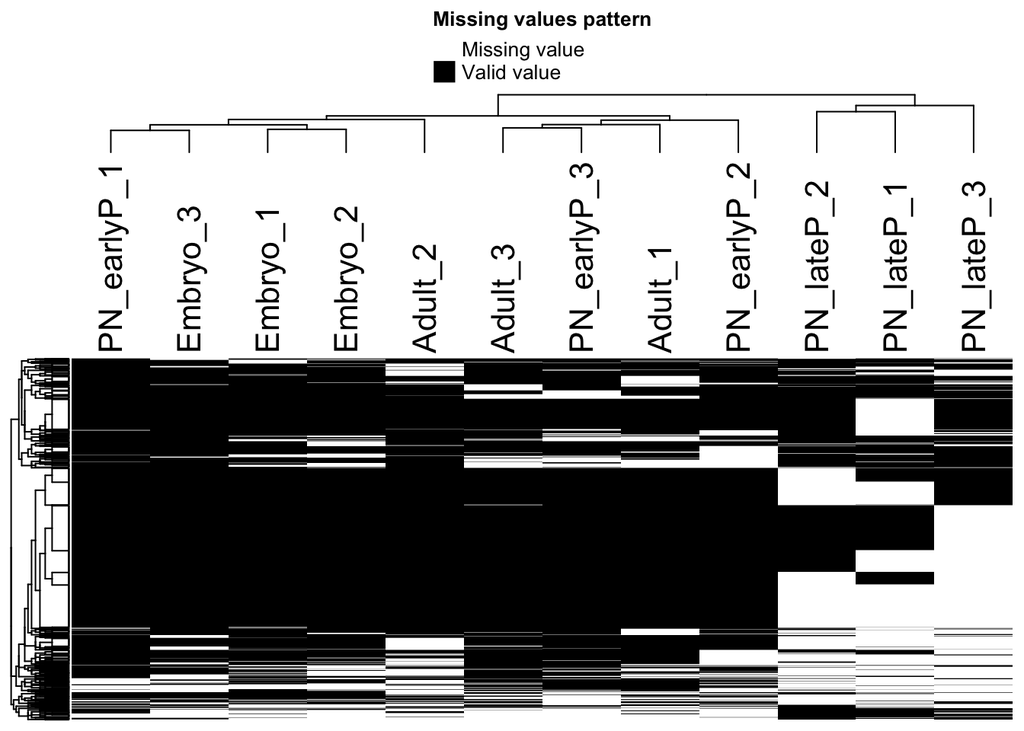

```r
data_norm %>% plot_missval()
```

# 7 Impute

```r
data_norm %>% DEP2::impute(. , fun = "GSimp", hi_q = 0.1,
                       iters_each=100, iters_all=20) -> data_imp
```

```
Imputing along margin 2 (samples/columns).
```

```
Iteration 1 start...end!
Iteration 2 start...end!
Iteration 3 start...end!
Iteration 4 start...end!
Iteration 5 start...end!
Iteration 6 start...end!
Iteration 7 start...end!
Iteration 8 start...end!
Iteration 9 start...end!
Iteration 10 start...end!
Iteration 11 start...end!
Iteration 12 start...end!
Iteration 13 start...end!
Iteration 14 start...end!
Iteration 15 start...end!
Iteration 16 start...end!
Iteration 17 start...end!
Iteration 18 start...end!
Iteration 19 start...end!
Iteration 20 start...end!
```

# 8 Imputation

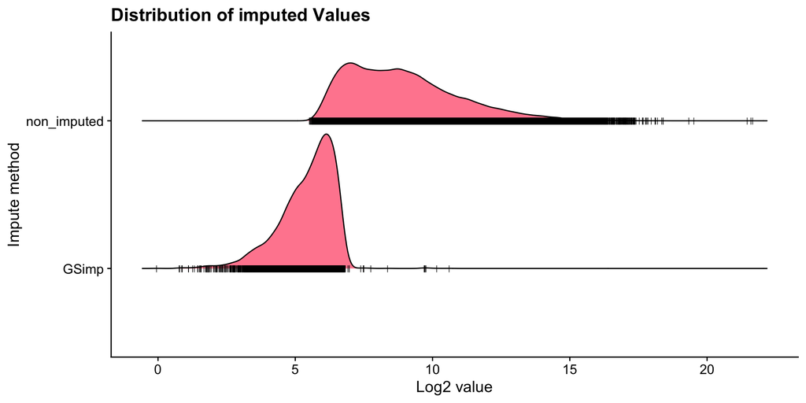

```r
NAs <- is.na(assay(data_norm))
## the imputed values by different methods.
imps <- assay(data_imp) %>% data.frame %>% gather("label", "value") %>%
      left_join(colData(data_imp)[c("label","condition")],copy = T) %>%
      magrittr::extract(as.vector(NAs),)%>% mutate(method = "GSimp")
nonimps <- assay(data_norm) %>% data.frame %>% gather("label", "value") %>%
  left_join(colData(data_norm)[c("label","condition")],copy = T) %>%
  magrittr::extract(!as.vector(NAs),) %>% mutate(method = "non_imputed") %>%
  dplyr::select(method,everything())
ggplot(rbind(imps, nonimps),aes(x = value,y = factor(method,level = unique(method)))) +
  geom_density_ridges(fill = "#ff506e", scale = .91,
                      jittered_points = TRUE,position = position_points_jitter(height = 0),
                      point_shape = '|', point_size = 2, point_alpha = 1, alpha = 0.7) +
  ylab("Impute method")+ xlab("Log2 value") +
  theme_cowplot()+ggtitle("Distribution of imputed Values")
```

# 9 Testing significant differences between conditions

BH correction of pval for multiple testing

```r
data_imp %>%  test_diff(type = "all", control = "Embryo", fdr.type = "BH") %>%
    add_rejections(alpha = 0.05, lfc = 1) -> data_test# alpha is the significance level, lfc is the log fold change threshold
```

```
Tested contrasts: PN_earlyP_vs_Embryo, PN_lateP_vs_Embryo, Adult_vs_Embryo, PN_earlyP_vs_PN_lateP, PN_earlyP_vs_Adult, PN_lateP_vs_Adult
```

```
BH
```

# 10 PCA

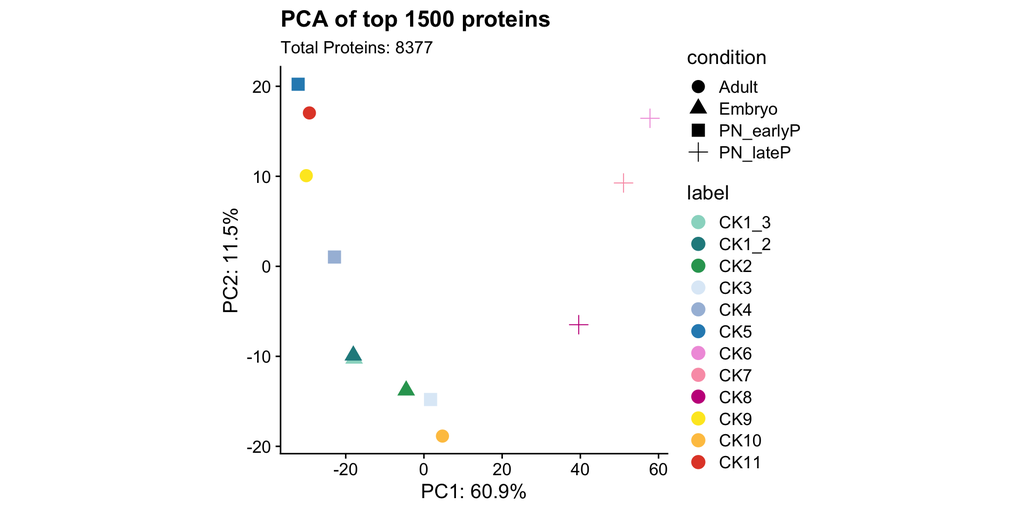

```r
  p<-plot_pca(data_test, label = F, n = 1500, features = "Proteins", indicate = c("label", "condition"))+
    scale_colour_manual(values = sample_color_vec)+
    theme_cowplot()+
    ggtitle(paste("PCA of top 1500 proteins"), subtitle = paste("Total Proteins:" , nrow(data_test)))+
  theme(aspect.ratio = 1)


  print(p)
```

## 10.1 PCA top 500

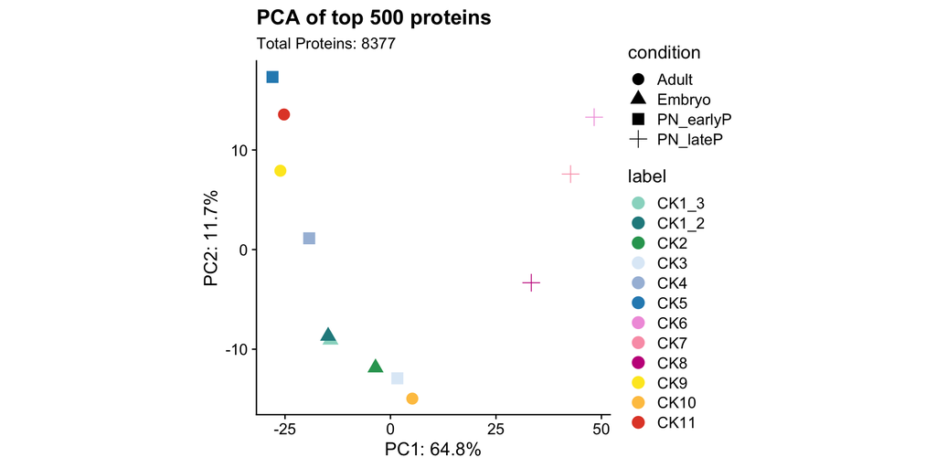

```r
  p<-plot_pca(data_test, label = F, n = 500, features = "Proteins", indicate = c("label", "condition"))+
    scale_colour_manual(values = sample_color_vec)+
    theme_cowplot()+
    ggtitle(paste("PCA of top 500 proteins"), subtitle = paste("Total Proteins:" , nrow(data_test)))+
  theme(aspect.ratio = 1)

  print(p)
```

## 10.2 PCA top 150

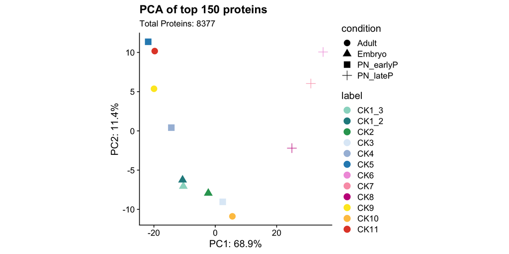

```r
  p<-plot_pca(data_test, label = F, n = 150, features = "Proteins", indicate = c("label", "condition"))+
    scale_colour_manual(values = sample_color_vec)+
    theme_cowplot()+
    ggtitle(paste("PCA of top 150 proteins"), subtitle = paste("Total Proteins:" , nrow(data_test)))+
  theme(aspect.ratio = 1)


    print(p)
```

## 10.3 PCA top 50

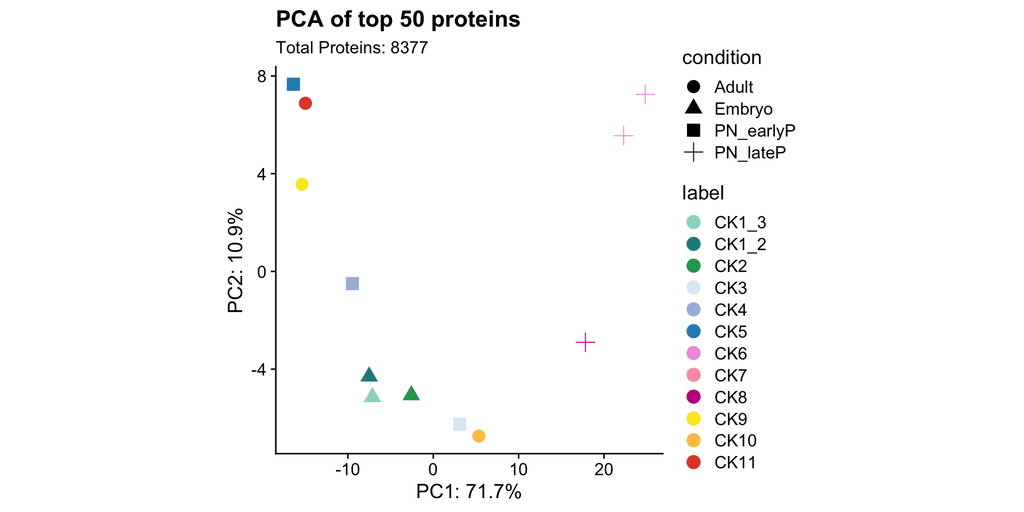

```r
  p<-plot_pca(data_test, label = F, n = 50, features = "Proteins", indicate = c("label", "condition"))+
    scale_colour_manual(values = sample_color_vec)+
    theme_cowplot()+
    ggtitle(paste("PCA of top 50 proteins"), subtitle = paste("Total Proteins:" , nrow(data_test)))+
  theme(aspect.ratio = 1)


  print(p)
```

# 11 Correlation

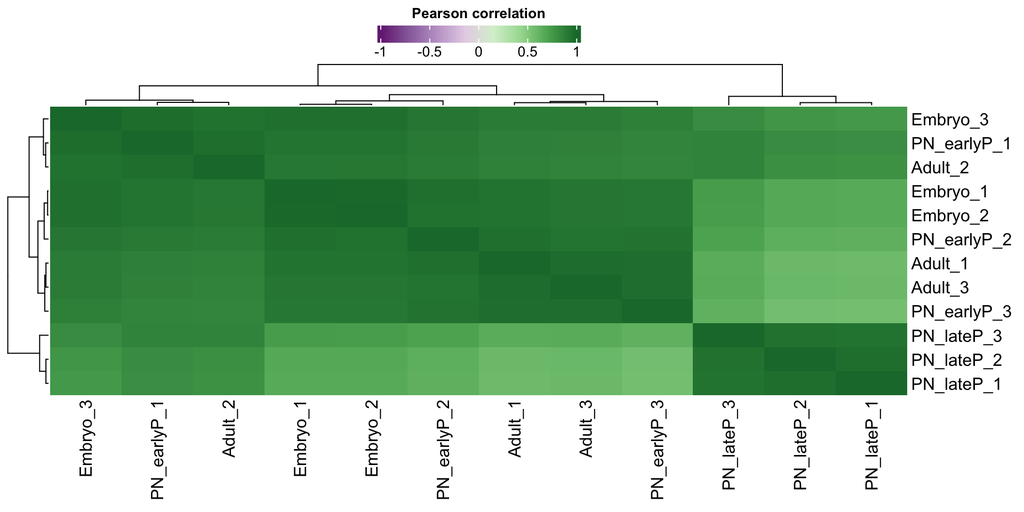

```r
plot_cor(data_test)
```

# 12 Saving SummarizedExperiment

```r
file = paste(path_results, "/",paste(date, "_KAC386_Pig_organoids_SE_marked.rds", sep = ""), sep ="")


saveRDS(data_test, file = file)
```